# Lab02

Hadrizia Santos

6 de novembro de 2017

**Carregando e modelando os dados**

Inicialmente carregam-se os dados a serem analisados:

Após uma análise rápida dos dados, percebeu-se que a ausência de dados em algumas tabelas é muito grande. Abaixo segue um gráfico que ilustra isso.

```r
 missmap(eleicoes2014)
```

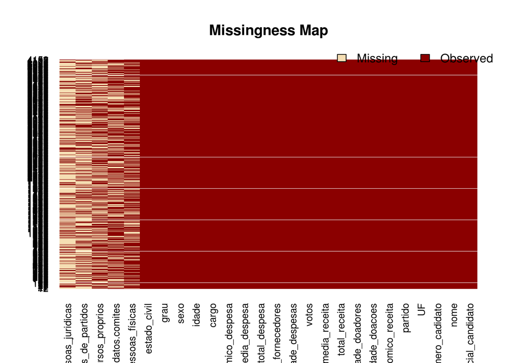

Através do gráfico acima, percebemos que faltam muitos dados nas colunas recursos_de_pessoas_juridicas, recursos_de_partidos, recursos_proprios, recursos_de_outros_candidatos.comites e recursos_de_pessoas_físicas. A abordagem utilizada para lidar com esta falta de dados é **preenchê-los com a mediana de cada coluna**:

```r
# Setando valores  NA para a média dos valores da coluna recursos_de_pessoas_juridicas
eleicoes2014$recursos_de_pessoas_juridicas[is.na(eleicoes2014$recursos_de_pessoas_juridicas)]<-median (eleicoes2014$recursos_de_pessoas_juridicas, na.rm = TRUE)

# Setando valores NA para a média dos valores da coluna recursos_de_partidos
eleicoes2014$recursos_de_partidos[is.na(eleicoes2014$recursos_de_partidos)]<-median (eleicoes2014$recursos_de_partidos, na.rm = TRUE)

#Setando valores NA para a média dos valores da coluna recursos_proprios
eleicoes2014$recursos_proprios[is.na(eleicoes2014$recursos_proprios)]<-median (eleicoes2014$recursos_proprios, na.rm = TRUE)

#Setando valores NA para a média dos valores da coluna recursos_de_outros_candidatos.comites
eleicoes2014$recursos_de_outros_candidatos.comites[is.na(eleicoes2014$recursos_de_outros_candidatos.comites)]<-median (eleicoes2014$recursos_de_outros_candidatos.comites, na.rm = TRUE)

#Setando valores NA para a média dos valores da coluna recursos_de_pessoas_físicas.
eleicoes2014$recursos_de_pessoas_físicas[is.na(eleicoes2014$recursos_de_pessoas_físicas)]<-median (eleicoes2014$recursos_de_pessoas_físicas, na.rm = TRUE)
```

Problema de falta de dados resolvidos, iremos agora responder às perguntas.

**1. Um modelo de regressão múltipla com todas as variáveis é plausível para explicar a variação em y (número de votos)? Justifique sua resposta.**

Por conter inúmeras variáveis categóricas o modelo ficou bastante extenso, dificultando a visualização. Foram excluídas as variáveis que obtiveram p-valor maior que 0,05, indicando que a probabilidade da causalidade entre a variável e a quantidade de votos ser aleatória é grande (não são boas preditoras para a quantidade de votos).

```r
input <- eleicoes2014
input$UF <- as.numeric(input$UF)
input$sexo <- as.numeric(input$sexo)
input$partido <- as.numeric(input$partido)
```

Concluindo as adaptações, agora cria-se o modelo de regressão:

```r
input <- input %>% select(-cargo, -nome, -grau, -estado_civil, -sequencial_candidato, -numero_cadidato, -idade, -setor_economico_receita, -setor_economico_despesa, -UF, -partido, -quantidade_doacoes)

voto.model <- lm(formula = votos ~ ., input, na.action = na.omit)

summary(voto.model)
```

```
##
## Call:
## lm(formula = votos ~ ., data = input, na.action = na.omit)
##
## Residuals:
##     Min      1Q  Median      3Q     Max
## -307808   -6563    -892    2302 1245332
##
## Coefficients:
##                                         Estimate Std. Error t value
## (Intercept)                            6.565e+03  2.555e+03   2.569
## quantidade_doadores                    2.379e+02  2.395e+01   9.934
## total_receita                          3.665e-01  3.909e-02   9.377
## media_receita                          4.022e-01  4.897e-02   8.213
## recursos_de_outros_candidatos.comites -2.364e-01  3.920e-02  -6.032
## recursos_de_partidos                  -3.300e-01  3.836e-02  -8.602
## recursos_de_pessoas_físicas           -3.269e-01  3.962e-02  -8.251
## recursos_de_pessoas_juridicas         -3.180e-01  3.830e-02  -8.303
## recursos_proprios                     -3.426e-01  3.862e-02  -8.871
## quantidade_despesas                    4.801e+01  4.212e+00  11.400
## quantidade_fornecedores               -5.473e+01  6.046e+00  -9.053
## total_despesa                         -2.808e-02  7.392e-03  -3.798
## media_despesa                          2.048e+00  3.935e-01   5.203
## sexo                                   2.364e+03  1.159e+03   2.039
##                                       Pr(>|t|)
## (Intercept)                           0.010238 *
## quantidade_doadores                    < 2e-16 ***
## total_receita                          < 2e-16 ***
## media_receita                         2.86e-16 ***
## recursos_de_outros_candidatos.comites 1.76e-09 ***
## recursos_de_partidos                   < 2e-16 ***
## recursos_de_pessoas_físicas            < 2e-16 ***
## recursos_de_pessoas_juridicas          < 2e-16 ***
## recursos_proprios                      < 2e-16 ***
## quantidade_despesas                    < 2e-16 ***
## quantidade_fornecedores                < 2e-16 ***
## total_despesa                         0.000148 ***
## media_despesa                         2.06e-07 ***
## sexo                                  0.041486 *
## ---
## Signif. codes:  0 '***' 0.001 '**' 0.01 '*' 0.05 '.' 0.1 ' ' 1
##
## Residual standard error: 32470 on 4138 degrees of freedom
## Multiple R-squared:  0.4874, Adjusted R-squared:  0.4857
## F-statistic: 302.6 on 13 and 4138 DF,  p-value: < 2.2e-16
```

**2. Todas as variáveis são úteis para o modelo de regressão? Há variáveis redudantes? Justifique sua resposta em ambos os casos.**

Precisamos selecionar as melhores variáveis de predição e eliminar as que não predizem y (quantidade de votos) e/ou são redundantes para o modelo. Para isso, utiliza-se um pacote do R chamado *corrplot* que exibe a correlação entre cada variável.

```r
corr = cor(input[, 1:14])
round(corr, 2)
```

```
##                                       quantidade_doadores total_receita
## quantidade_doadores                                  1.00          0.46
## total_receita                                        0.46          1.00
## media_receita                                        0.09          0.60
## recursos_de_outros_candidatos.comites                0.20          0.42
## recursos_de_partidos                                 0.24          0.82
## recursos_de_pessoas_físicas                          0.63          0.57
## recursos_de_pessoas_juridicas                        0.42          0.80
## recursos_proprios                                    0.15          0.38
## votos                                                0.42          0.62
## quantidade_despesas                                  0.48          0.81
## quantidade_fornecedores                              0.44          0.72
## total_despesa                                        0.46          0.99
## media_despesa                                        0.13          0.37
## sexo                                                 0.12          0.14
##                                       media_receita
## quantidade_doadores                            0.09
## total_receita                                  0.60
## media_receita                                  1.00
## recursos_de_outros_candidatos.comites          0.19
## recursos_de_partidos                           0.59
## recursos_de_pessoas_físicas                    0.22
## recursos_de_pessoas_juridicas                  0.40
## recursos_proprios                              0.20
## votos                                          0.43
## quantidade_despesas                            0.38
## quantidade_fornecedores                        0.33
## total_despesa                                  0.59
## media_despesa                                  0.54
## sexo                                           0.14
##                                       recursos_de_outros_candidatos.comites
## quantidade_doadores                                                    0.20
## total_receita                                                          0.42
## media_receita                                                          0.19
## recursos_de_outros_candidatos.comites                                  1.00
## recursos_de_partidos                                                   0.23
## recursos_de_pessoas_físicas                                            0.24
## recursos_de_pessoas_juridicas                                          0.25
## recursos_proprios                                                      0.08
## votos                                                                  0.42
```

[output cut: 95 more lines]

```
##                                       total_despesa media_despesa sexo
## quantidade_doadores                            0.46          0.13 0.12
## total_receita                                  0.99          0.37 0.14
## media_receita                                  0.59          0.54 0.14
## recursos_de_outros_candidatos.comites          0.42          0.12 0.08
## recursos_de_partidos                           0.81          0.37 0.10
## recursos_de_pessoas_físicas                    0.57          0.18 0.11
## recursos_de_pessoas_juridicas                  0.80          0.24 0.11
## recursos_proprios                              0.37          0.09 0.05
## votos                                          0.61          0.30 0.16
## quantidade_despesas                            0.81          0.08 0.12
## quantidade_fornecedores                        0.72          0.05 0.09
## total_despesa                                  1.00          0.37 0.14
## media_despesa                                  0.37          1.00 0.12
## sexo                                           0.14          0.12 1.00
```

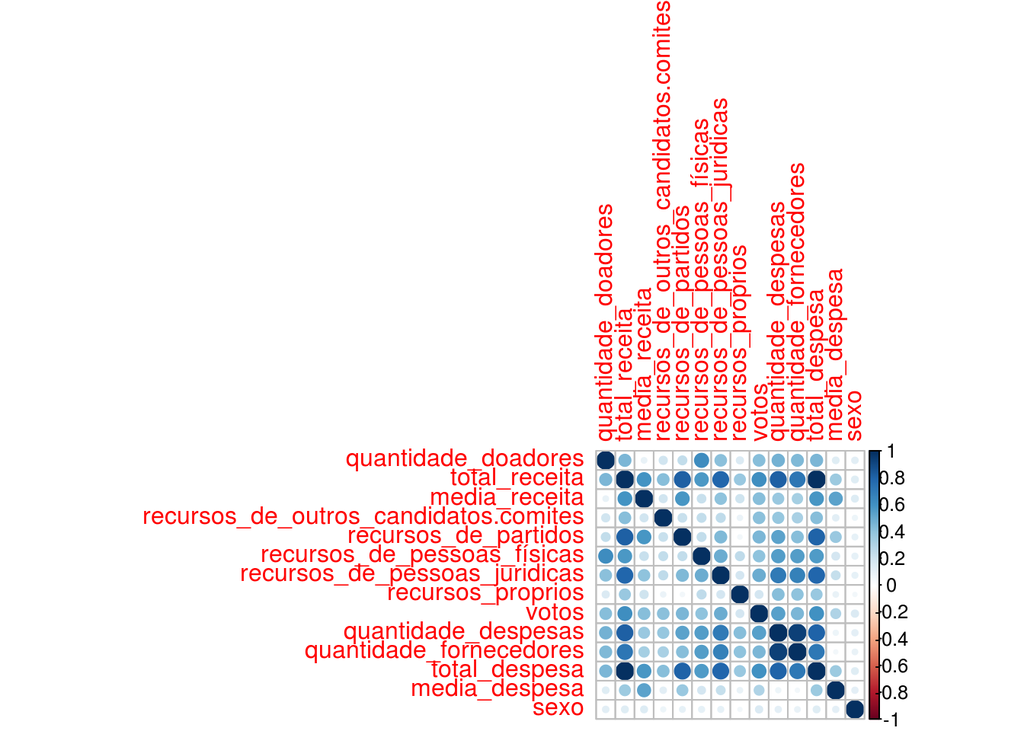

```r
corrplot(corr, method="circle")
```

**3. No caso de haver variáveis pouco explicativas e/ou redudantes, construa um novo modelo sem essas variáveis e o compare ao modelo com todas as variáveis (e.g. em termos de R2 e RSE).**

```r
input <- input %>% select(-total_despesa)

voto.model <- lm(formula = votos ~ ., input, na.action = na.omit)

summary(voto.model)
```

```
##
## Call:
## lm(formula = votos ~ ., data = input, na.action = na.omit)
##
## Residuals:
##     Min      1Q  Median      3Q     Max
## -299823   -6609    -908    2293 1247278
##
## Coefficients:
##                                         Estimate Std. Error t value
## (Intercept)                           6633.37178 2559.52834   2.592
## quantidade_doadores                    236.91275   23.99003   9.875
## total_receita                            0.33756    0.03840   8.790
## media_receita                            0.41372    0.04896   8.451
## recursos_de_outros_candidatos.comites   -0.23615    0.03926  -6.015
## recursos_de_partidos                    -0.32909    0.03842  -8.565
## recursos_de_pessoas_físicas             -0.32562    0.03968  -8.206
## recursos_de_pessoas_juridicas           -0.31920    0.03836  -8.321
## recursos_proprios                       -0.34205    0.03869  -8.842
## quantidade_despesas                     46.96986    4.20949  11.158
## quantidade_fornecedores                -52.67843    6.03140  -8.734
## media_despesa                            2.00658    0.39403   5.093
## sexo                                  2351.18254 1161.28915   2.025
##                                       Pr(>|t|)
## (Intercept)                            0.00959 **
## quantidade_doadores                    < 2e-16 ***
## total_receita                          < 2e-16 ***
## media_receita                          < 2e-16 ***
## recursos_de_outros_candidatos.comites 1.95e-09 ***
## recursos_de_partidos                   < 2e-16 ***
## recursos_de_pessoas_físicas           3.03e-16 ***
## recursos_de_pessoas_juridicas          < 2e-16 ***
## recursos_proprios                      < 2e-16 ***
## quantidade_despesas                    < 2e-16 ***
## quantidade_fornecedores                < 2e-16 ***
## media_despesa                         3.69e-07 ***
## sexo                                   0.04297 *
## ---
## Signif. codes:  0 '***' 0.001 '**' 0.01 '*' 0.05 '.' 0.1 ' ' 1
##
## Residual standard error: 32530 on 4139 degrees of freedom
## Multiple R-squared:  0.4856, Adjusted R-squared:  0.4841
## F-statistic: 325.6 on 12 and 4139 DF,  p-value: < 2.2e-16
```

O modelo anterior considerando algumas das variáveis possui RSE = 32.470 e R² ajustado = 0.4857, enquanto que este apresentou RSE = 32.530 e R² ajustado = 0.4841. Acredito que, considerando que a taxa de aumento de erro e de diminuição do R² ajustado foi baixa, então a retirada da variável total_despesa não acarretou em mudanças muito drásticas no modelo.

**4. Analise plots de resíduos e verifique se há tendências nos erros.**

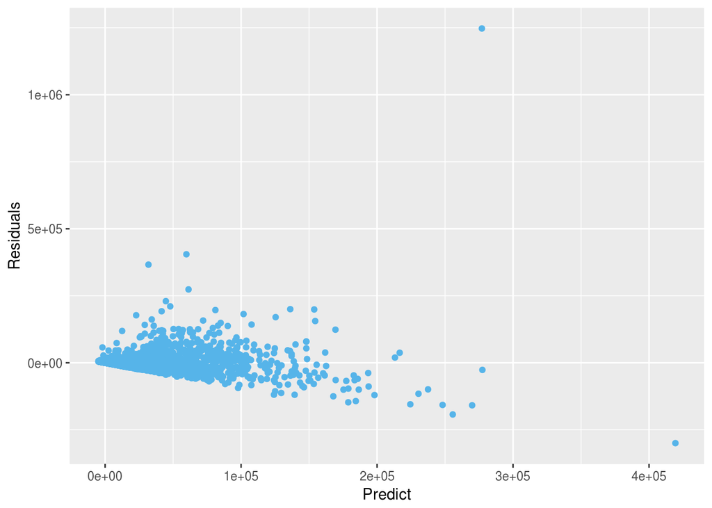

```r
ggplot(voto.model, aes(x = predict(voto.model), y = residuals(voto.model))) +
  geom_point(color = "#56B4E9") +
  xlab("Predict") +
  ylab("Residuals")
```

Observando o gráfico, percebemos que os resíduos são assimétrico e possuem um padrão de comportamento (não são aleatórios). Isto indica que o modelo não é ideal e que faltam transformações ou interações entre as variáveis, que serão feitas nos próximos labs.

**5. Quais variáveis conseguem explicar melhor o número de votos? Justifique sua resposta.** Para saber quais variáveis explicam melhor o número de votos, utiliza-se um pacote do R chamado *leaps* que procura o melhor subconjunto das variáveis em x que predizem y.

```r
regsubconj <-
    regsubsets(votos ~ .,
               data = input,
               nbest = 1,       # seleciona um melhor modelo para cada numero de preditores
               nvmax = NULL,    # Sem limites de variaveis
               force.in = NULL, force.out = NULL,
               method = "exhaustive",
               really.big = T)

summary_regsubconj <- summary(regsubconj)
summary_regsubconj
```

```
## Subset selection object
## Call: regsubsets.formula(votos ~ ., data = input, nbest = 1, nvmax = NULL,
##     force.in = NULL, force.out = NULL, method = "exhaustive",
##     really.big = T)
## 12 Variables  (and intercept)
##                                       Forced in Forced out
## quantidade_doadores                       FALSE      FALSE
## total_receita                             FALSE      FALSE
## media_receita                             FALSE      FALSE
## recursos_de_outros_candidatos.comites     FALSE      FALSE
## recursos_de_partidos                      FALSE      FALSE
## recursos_de_pessoas_físicas               FALSE      FALSE
## recursos_de_pessoas_juridicas             FALSE      FALSE
## recursos_proprios                         FALSE      FALSE
## quantidade_despesas                       FALSE      FALSE
```

[output cut: 70 more lines]

O resultado é o melhor modelo de subconjuntos de todo tamanho começando em 1 variável até 12, que é o número total de variáveis. A seguir precisamos saber qual é o melhor modelo entre estes e o critério de escolha será o R² ajustado, que define o quanto as variáveis explicam os votos.

```r
melhor_modelo <- which.max(summary_regsubconj$adjr2)
melhor_modelo
```

```
## [1] 12
```

A função acima procura, entre todos os modelos dos subconjuntos das variáveis, qual o modelo que possui maior R² ajustado (nesse caso, foi o modelo com todas as variáveis):

```r
summary_regsubconj$which[melhor_modelo,]
```

```
##                           (Intercept)
##                                  TRUE
##                   quantidade_doadores
##                                  TRUE
##                         total_receita
##                                  TRUE
##                         media_receita
##                                  TRUE
## recursos_de_outros_candidatos.comites
##                                  TRUE
##                  recursos_de_partidos
##                                  TRUE
##           recursos_de_pessoas_físicas
##                                  TRUE
##         recursos_de_pessoas_juridicas
##                                  TRUE
##                     recursos_proprios
##                                  TRUE
##                   quantidade_despesas
##                                  TRUE
##               quantidade_fornecedores
##                                  TRUE
##                         media_despesa
##                                  TRUE
##                                  sexo
##                                  TRUE
```

Como se pode ver acima, todas as variáveis preditoras. **Exportando os dados para serem utilizados futuramente:**

```r
write.csv(input, 'input_eleicoes2014.csv', row.names=FALSE)
```